[figure not shown]

<h1, align=center>PYTHON OBJECTS AND CLASSES</h1>

# Welcome!

Objects in programming are like objects in real life. Like life, there are different classes of objects. In this notebook, we will create two classes called Circle and Rectangle. By the end of this notebook, you will have a better idea about :

-what a class is

-what an attribute is

-what a method is

Don’t worry if you don’t get it the first time as much of the terminology is confusing. Don’t forget to do the practice tests in the notebook.

### Introduction

#### Creating a Class

The first part of creating a class is giving it a name, in this notebook, we will create two classes Circle and Rectangle. We need to determine all the data that make up that class; we call that an attribute. Think about this step as creating a blue print; we will use this blueprint to create objects. This is shown in figure 1 we see to classes circle and rectangle; each has their attributes, they are variables. The class circle has the attribute radius and colour, the rectangle has the attribute height and width. Let’s use the visual examples of these shapes before we get to the code; this will help you get accustomed to the vocabulary.

<img src = "https://ibm.box.com/shared/static/h2w03relr84lb8ofto2zk0dp9naiykfg.png" width = 500, align = "center"></a> <h4 align=center>

#### Figure 1: to classes circle and rectangle, each has their own attributes. The class circle has the attribute radius and colour, the rectangle has the attribute height and width.

#### Instances of a Class: Objects and Attributes

An instance of an object is the realisation of a class, in figure 2 we see three instances of the class circle. We give each object a name, red circle, yellow circle and green circle; each object has different attributes, let's focus on the attribute of colour for each object.

<img src = "https://ibm.box.com/shared/static/bz20uxc78sbv8knixnl3a52z2u2r74zp.png" width = 500, align = "center"></a> <h4 align=center> Figure 2: Three instances of the class circle or three objects of type circle.

The color attribute for the red circle is the color red, for the green circle object the color attribute the green and for the yellow circle the color attribute is yellow.

#### Methods

Methods give you a way to change or interact with the object, they are functions that interact with objects. For example, let’s say we would like to increase the radius by a specified amount of a circle. We can create a method called **add_radius(r)** that increases the radius by **r**. This is shown in figure 3 after applying the method to the "orange circle object" the radius of the object increases accordingly. The “dot” notation means to apply the method to the object.

<img src = "https://ibm.box.com/shared/static/53b39xh7snepk0my8z7t9n9wzres4drf.png" width = 500, align = "center"></a> <h4 align=center> Figure 3: Applying the method “add_radius” to the object orange circle object .

# Creating a Class

Now we are going to create a class circle, but first, we are going to import a library to draw the objects:

```python
import matplotlib.pyplot as plt
%matplotlib inline
```

The first step is creating your own class is to use the **class** keyword, then the name of the class as shown in figure 4. In this course the class parent, will always be object.

<img src = "https://ibm.box.com/shared/static/q9394f3aip7lbu4k1yct5pczst5ec3sk.png" width = 400, align = "center"></a> <h4 align=center> Figure 4: Three instances of the class circle or three objects of type circle.

The next step is a special method called a constructor **init**, this method is used to initialize the object, the input are data attributes. The term **self** contains all the attributes in the set. For example the **self.color** gives the value of the attribute color and **self.radius** will give you the radius of the object. We also have the method **add_radius()** with the parameter **r**, the method adds the value of **r** to the attribute radius. To access the radius we use the sintax **self.radius**, the labeled syntax is summarized in figure 5.

<img src = "https://ibm.box.com/shared/static/25j0jezklf6snhh3ps61d0djzwx8kgwa.png" width = 600, align = "center"></a> <h4 align=center> Figure 5: Labeled syntax of the object circle.

The actual object is shown below; we include the method drawCircle to display the image of a circle. We set the default radius to 3 and the default colour to blue.

```python
class Circle(object):

    def __init__(self,radius=3,color='blue'):

        self.radius=radius
        self.color=color

    def add_radius(self,r):

        self.radius=self.radius+r
        return(self.radius)
    def drawCircle(self):

        plt.gca().add_patch(plt.Circle((0, 0), radius=self.radius, fc=self.color))
        plt.axis('scaled')
        plt.show()
```

### Creating an instance of a class Circle

Let’s create the object **RedCircle** of type Circle do the following:

```python
RedCircle=Circle(10,'red')
```

We can use the **dir** command to get a list of the object's methods. Many of them are default Python methods.

```python
dir(RedCircle)
```

```
['__class__',
 '__delattr__',
 '__dict__',
 '__dir__',
 '__doc__',
 '__eq__',
 '__format__',
 '__ge__',
 '__getattribute__',
 '__gt__',
 '__hash__',
 '__init__',
 '__le__',
 '__lt__',
 '__module__',
 '__ne__',
 '__new__',
 '__reduce__',
 '__reduce_ex__',
 '__repr__',
 '__setattr__',
 '__sizeof__',
 '__str__',
 '__subclasshook__',
 '__weakref__',
 'add_radius',
 'color',
 'drawCircle',
 'radius']
```

We can look at the data attributes of the object

```python
RedCircle.radius
```

```
10
```

```python
RedCircle.color
```

```
'red'
```

we can change the object's data attributes

```python
RedCircle.radius=1
```

```python
RedCircle.radius
```

```
1
```

We can draw the object by using the method **drawCircle()**

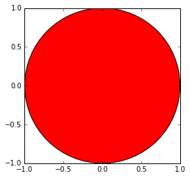

```python
RedCircle.drawCircle()
```

We can increase the radius of the circle by applying the method **add_radius()**. Let increases the radius by 2 and then by 5:

```python
print('Radius of object:',RedCircle.radius)
RedCircle.add_radius(2)
print('Radius of object of after applying the method add_radius(2):',RedCircle.radius)
RedCircle.add_radius(5)
print('Radius of object of after applying the method add_radius(5):',RedCircle.radius)
```

[output not shown]

Let’s create a blue circle, as the default colour is blue all we have to do is specify what the radius is.

```python
BlueCircle=Circle(radius=100)
```

As before we can access the attributes of the instance of the class by using the dot notation:

```python
BlueCircle.radius
```

```
100
```

```python
BlueCircle.color
```

```
'blue'
```

We can draw the object by using the method **drawCircle()**

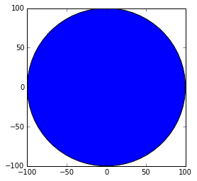

```python
BlueCircle.drawCircle()
```

Compare the x and y axis of the figure to the figure for **RedCircle** they are different.

### The Rectangle Class

Let's create a class rectangle the attributes will be height, width and color. We will only add the method to draw the rectangle object.

```python
class Rectangle(object):

    def __init__(self,width=2,height =3,color='r'):
        self.height=height
        self.width=width
        self.color=color

    def drawRectangle(self):
        import matplotlib.pyplot as plt
        plt.gca().add_patch(plt.Rectangle((0, 0),self.width, self.height ,fc=self.color))
        plt.axis('scaled')
        plt.show()
```

```python
SkinnyBlueRectangle= Rectangle(2,10,'blue')
```

As before we can access the attributes of the instance of the class by using the dot notation:

```python
SkinnyBlueRectangle.height
```

```
10
```

```python
SkinnyBlueRectangle.width
```

```
2
```

```python
SkinnyBlueRectangle.color
```

```
'blue'
```

We can draw the object:

```python
SkinnyBlueRectangle.drawRectangle()
```

[output not shown]

Let’s create the object “FatYellowRectangle” of type Rectangle :

```python
FatYellowRectangle = Rectangle(20,5,'yellow')
```

We can access the attributes of the instance of the class by using the dot notation:

```python
FatYellowRectangle.height
```

```
5
```

```python
FatYellowRectangle.width
```

```
20
```

```python
FatYellowRectangle.color
```

```
'yellow'
```

We can draw the object:

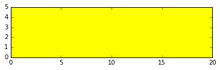

```python
FatYellowRectangle.drawRectangle()
```

#### Hi Joseph here, check out my other course Data Analysis with Python, just click the image below:

[figure not shown]

#### Enjoying Python? Think ahead about what you might want to use in the future.

If you're looking for a enterprise-ready environment to use Python on a big scale with two free Apache Spark executors, consider signing up for a free account on [Data Science Experience](http://cocl.us/NotebooksPython101bottom)

# About the Authors:

[Joseph Santarcangelo](https://www.linkedin.com/in/joseph-s-50398b136/) has a PhD in Electrical Engineering, his research focused on using machine learning, signal processing, and computer vision to determine how videos impact human cognition. Joseph has been working for IBM since he completed his PhD.

Copyright © 2017 [Cognitiveclass.ai](https://cognitiveclass.ai/?utm_source=bducopyrightlink&utm_medium=dswb&utm_campaign=bdu). This notebook and its source code are released under the terms of the [MIT License](https://bigdatauniversity.com/mit-license/).